# Statistical inference project 2

YOUNGSANG KIM

2020 12 13

## Instructions

1. Load the ToothGrowth data and perform some basic exploratory data analyses
2. Provide a basic summary of the data.
3. Use confidence intervals and/or hypothesis tests to compare tooth growth by supp and dose. (Only use the techniques from class, even if there’s other approaches worth considering)
4. State your conclusions and the assumptions needed for your conclusions.

### EDA

```r
#Load required packages
library(dplyr, warn.conflicts = F)
library(ggplot2)
library(ggthemes)
# Load ToothGrowth data
data("ToothGrowth")

# Display a summary of the data
summary(ToothGrowth)
```

```
##       len        supp         dose
##  Min.   : 4.20   OJ:30   Min.   :0.500
##  1st Qu.:13.07   VC:30   1st Qu.:0.500
##  Median :19.25           Median :1.000
##  Mean   :18.81           Mean   :1.167
##  3rd Qu.:25.27           3rd Qu.:2.000
##  Max.   :33.90           Max.   :2.000
```

```r
str(ToothGrowth)
```

```
## 'data.frame':    60 obs. of  3 variables:
##  $ len : num  4.2 11.5 7.3 5.8 6.4 10 11.2 11.2 5.2 7 ...
##  $ supp: Factor w/ 2 levels "OJ","VC": 2 2 2 2 2 2 2 2 2 2 ...
##  $ dose: num  0.5 0.5 0.5 0.5 0.5 0.5 0.5 0.5 0.5 0.5 ...
```

Convert dose to a factor

```r
ToothGrowth$dose<-as.factor(ToothGrowth$dose)
```

Plot tooth length (‘len’) vs. the dose amount (‘dose’), broken out by supplement delivery method (‘supp’)

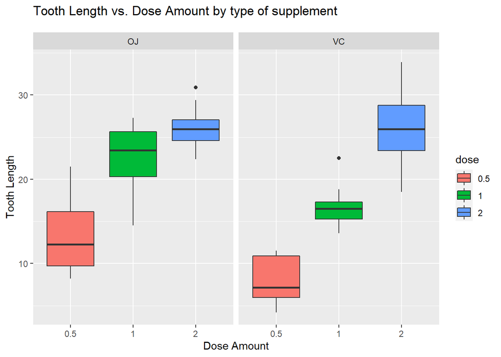

```r
ggplot(aes(x=dose, y=len), data=ToothGrowth) +
  geom_boxplot(aes(fill=dose)) +
  xlab("Dose Amount") +
  ylab("Tooth Length") +
  facet_grid(~ supp) +
  ggtitle("Tooth Length vs. Dose Amount by type of supplement
          ") +
  theme(plot.title = element_text(lineheight=.6))
```

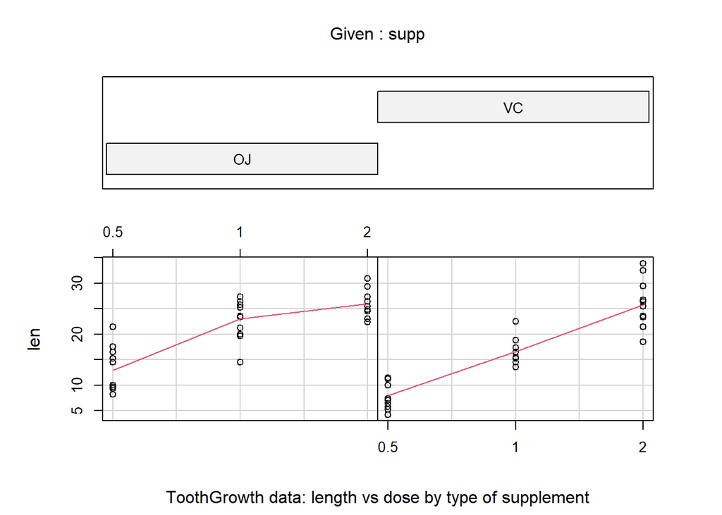

```r
coplot(len ~ dose | supp, data = ToothGrowth, panel = panel.smooth,
       xlab = "ToothGrowth data: length vs dose by type of supplement")
```

Plot tooth length (‘len’) vs. supplement delivery method (‘supp’) broken out by the dose amount (‘dose’)

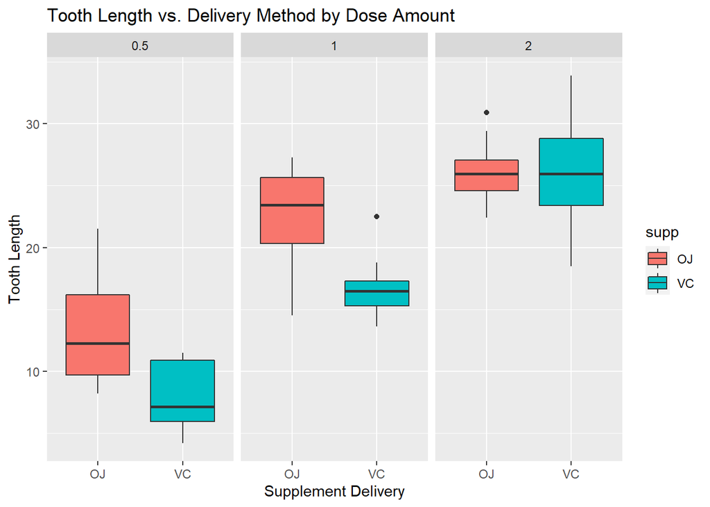

```r
ggplot(aes(x=supp, y=len), data=ToothGrowth) +
  geom_boxplot(aes(fill=supp)) +
  xlab("Supplement Delivery") +
  ylab("Tooth Length") +
  facet_grid(~ dose) +
  ggtitle("Tooth Length vs. Delivery Method by Dose Amount") +
  theme(plot.title = element_text(lineheight=.6))
```

### Hypothesis Tests

Now we want to further compare teeth growth by supplement type and dose levels.  
This time we’ll use statistical tests, t-test.

#### Test 1, dose = 0.5 and 1

```r
#Exract the len and dose vectors from the df ToothGrowth
len_1 <- ToothGrowth %>% filter(dose %in% c(0.5,1)) %>% select(len) %>% unlist()
dose_1 <- ToothGrowth %>% filter(dose %in% c(0.5,1)) %>% select(dose) %>% unlist()
#Test
(Test.1 <- t.test(len_1 ~ dose_1, paired = FALSE))
```

```
##
##  Welch Two Sample t-test
##
## data:  len_1 by dose_1
## t = -6.4766, df = 37.986, p-value = 1.268e-07
## alternative hypothesis: true difference in means is not equal to 0
## 95 percent confidence interval:
##  -11.983781  -6.276219
## sample estimates:
## mean in group 0.5   mean in group 1
##            10.605            19.735
```

#### Test 2 , dose = 0.5 and 2

```r
#Exract the len and dose vectors from the df ToothGrowth
len_2 <- ToothGrowth %>% filter(dose %in% c(0.5,2)) %>% select(len) %>% unlist()
dose_2 <- ToothGrowth %>% filter(dose %in% c(0.5, 2)) %>% select(dose) %>% unlist()
#Test
(Test.2 <- t.test(len_2 ~ dose_2, paired = FALSE))
```

```
##
##  Welch Two Sample t-test
##
## data:  len_2 by dose_2
## t = -11.799, df = 36.883, p-value = 4.398e-14
## alternative hypothesis: true difference in means is not equal to 0
## 95 percent confidence interval:
##  -18.15617 -12.83383
## sample estimates:
## mean in group 0.5   mean in group 2
##            10.605            26.100
```

#### Test 3, dose = 1 and 2

```r
#Exract the len and dose vectors from the df ToothGrowth
len_3 <- ToothGrowth %>% filter(dose %in% c(1,2)) %>% select(len) %>% unlist()
dose_3 <- ToothGrowth %>% filter(dose %in% c(1,2)) %>% select(dose) %>% unlist()
#Test c
(Test.3 <- t.test(len_3 ~ dose_3, paired = FALSE))
```

```
##
##  Welch Two Sample t-test
##
## data:  len_3 by dose_3
## t = -4.9005, df = 37.101, p-value = 1.906e-05
## alternative hypothesis: true difference in means is not equal to 0
## 95 percent confidence interval:
##  -8.996481 -3.733519
## sample estimates:
## mean in group 1 mean in group 2
##          19.735          26.100
```

We went through all possible combinations of levels.  
Thus, we reject Ho. In other words there appears to be a positive relationship between dose level and teeth length

#### Testing by Supplement

```r
#Exract the len and supp vectors from the df ToothGrowth
len <- ToothGrowth %>% select(len) %>% unlist()
supp <- ToothGrowth %>% select(supp) %>% unlist()
#Test
t.test(len~supp, paired=F)
```

```
##
##  Welch Two Sample t-test
##
## data:  len by supp
## t = 1.9153, df = 55.309, p-value = 0.06063
## alternative hypothesis: true difference in means is not equal to 0
## 95 percent confidence interval:
##  -0.1710156  7.5710156
## sample estimates:
## mean in group OJ mean in group VC
##         20.66333         16.96333
```

The p-value is 0.06, and the confidence interval contains zero.  
This indicates that we can not reject the null hypothesis that the different supplement types have no effect on tooth length.

### Conclusions

Given the following assumption:  
A. The sample is representative of the population.  
B. The distribution of the sample means follows the Central Limit Theorem.